# POLISCI 9590 - Lab7: Hypothesis Tests and Data Cleaning 2

William Poirier

2024-11-12

## 0. What we'll be doing

1. Hypothesis Tests
2. Cleaning Data Take 2

## 1. Hypothesis Testing

### 1.1 Confidence intervals

- **There can only be ONE!!!** How do we know where our sample stand in the sampling distribution???
- **Confidence intervals**: created such that $(1-\alpha)\%$ of the intervals we could make from different samples will cover the true, but unknown population value.
  - Hence, the only thing we can say is that, if $alpha$ is small enough, we are *willing to bet* that we are in one of the good samples.
  - Can be computed following $\bar X\pm z_{crit}\frac{sd_x}{\sqrt{n}}$

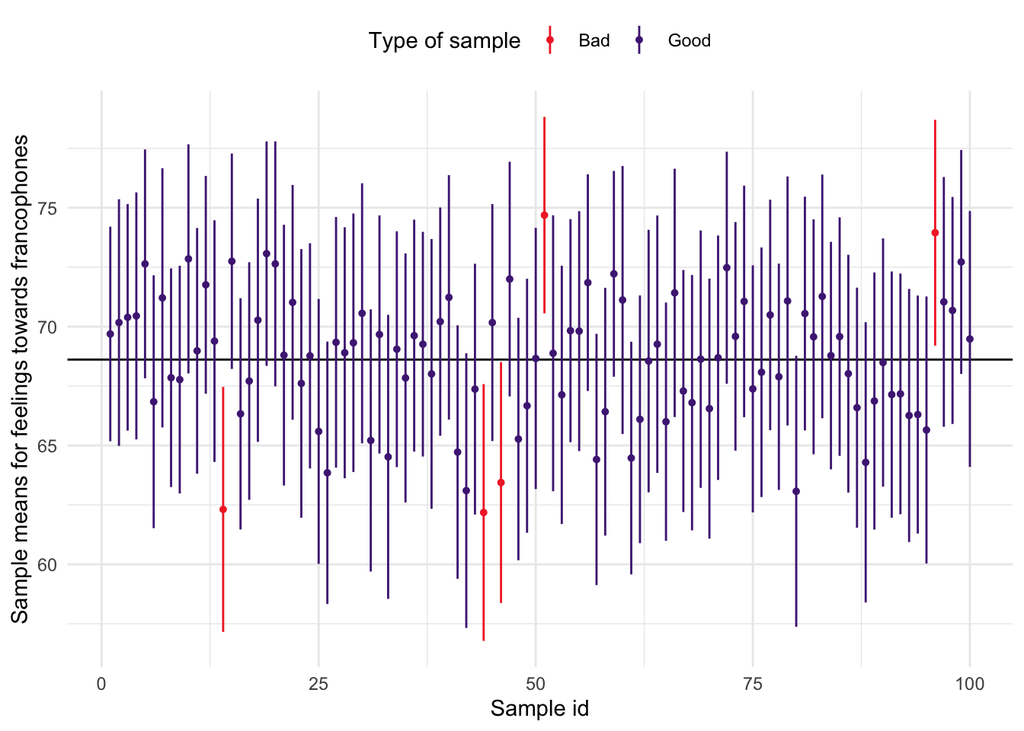

### 1.2 P-values and Hypothesis tests

- We know from the Weak Law of Large Numbers that our sample mean converges to the population mean as $n$ increases.
- We know from the Central Limit Theorem that our sampling distribution will be Normal (or Student's t for small samples).
- Setting our null hypothesis as $\mu_0=0$, we know that either:
  $$\bar Y \sim
  N(\mu,\frac{sd_Y}{\sqrt{n}})~~\text{or}~~\bar Y \sim
  t_{n-1}(\mu,\frac{sd_Y}{\sqrt{n}})$$
- Therefore, we can compute $z$ or $t$ scores depending on our sample size:
  $$z=\frac{\bar
  Y-\mu_0}{\sigma}~~\text{or}~~t=\frac{\bar
  Y-\mu_0}{\frac{sd_Y}{\sqrt{n}}}$$
  - Essentially how many standard deviations below or above $\mu_0$ an observation $\bar Y$ is.
  - We use the $z$ or $t$ scores to compute our p-values.

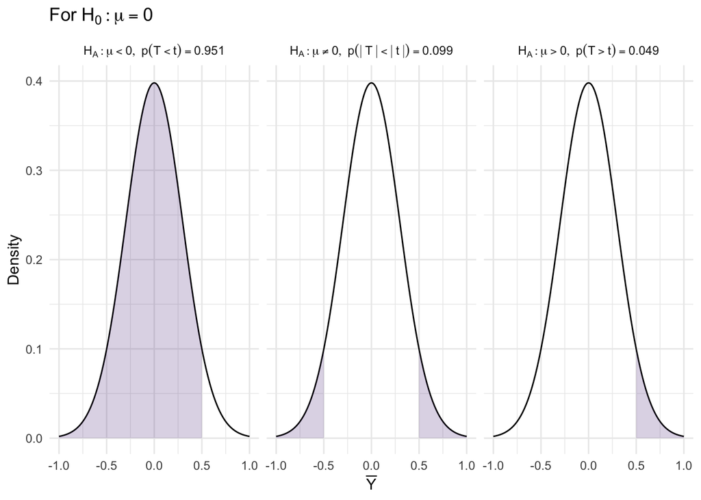

- For **proportion**, we use the $z$ distribution where $se=sd_Y=\sqrt{\frac{p(1-p)}{n}}$.
  - But, we need $np\geq5$ AND $n(1-p)\geq5$ for the normal approximation to work.
  - Where $n$ is the sample size and $p$ is the hypothesized population proportion (our $\mu_0$ from above).
- For **difference of means**:
  - Usually we have $H_0: \mu_0=0$.
  - For two means we have $H_0=\mu_1=\mu_2$ or $H_0=\mu_1-\mu_2=0$, hence:
    - $H_A:\mu_1\neq\mu_2 \rightarrow H_A:\mu_1-\mu_2\neq0$
    - $H_A:\mu_1<\mu_2 \rightarrow H_A:\mu_1-\mu_2<0$
    - $H_A:\mu_1>\mu_2 \rightarrow H_A:\mu_1-\mu_2>0$
  - So, our $z-$ or $t-$statistic: $\frac{Estimate~-~H_0Value}{SE}$, with $SE=\sqrt{\frac{\sigma^2_1}{n_1}+\frac{\sigma^2_2}{n_2}}$.
  - **Paired** t-tests imply that you have the same observations but different variables for both means.

### 1.3 R functions

- For usual hypothesis tests:
  - One sided `t.test(x, mu = 0, alternative="less")` OR `t.test(x, mu = 0, alternative="greater")`
  - Two sided `t.test(x, mu = 0, alternative="two")`
- For hypothesis tests regarding proportions:
  - `prop.test(x,n,p="NULL",alternative=c("two.sided", "less", "greater"))`, with `x` our vector of successes, `n` our total nb of observations and `p` our tested probability of success.
- For differences in means:
  - You can use `t.test(dat$group1,dat$group2,alternative="two",paired=F/T)`, but `tTest("group1","group2",data=dat,var.equal=F)` is more flexible.

### 1.4 Translation and Interpretation

- For the following, define the null and the alternative hypothesis, and compute the result with the appropriate test.
  1. Is the mean of `pplFeel_Francophones` for PEI folks different from 50?
  2. Is the mean of `pplFeel_Francophones` for PEI folks greater than 50?
  3. Is the mean of `pplFeel_Francophones` for PEI folks smaller than 50?
1. $H_0: \text{pplFeel_Francophones}_{PEI}=50$, $H_A: \text{pplFeel_Francophones}_{PEI} \neq 50$
2. $H_0: \text{pplFeel_Francophones}_{PEI}=50$, $H_A: \text{pplFeel_Francophones}_{PEI} > 50$
3. $H_0: \text{pplFeel_Francophones}_{PEI}=50$, $H_A: \text{pplFeel_Francophones}_{PEI} < 50$

```r
PEI <- CES |> filter(prov=="Prince Edward Island")
# 1.
t.test(PEI$pplFeel_Francophones,mu=50,alternative="two")
```

```
##
##  One Sample t-test
##
## data:  PEI$pplFeel_Francophones
## t = 0.42165, df = 11, p-value = 0.6814
## alternative hypothesis: true mean is not equal to 50
## 95 percent confidence interval:
##  36.28513 70.21487
## sample estimates:
## mean of x
##     53.25
```

```r
# 2.
t.test(PEI$pplFeel_Francophones,mu=50,alternative="greater")
```

```
##
##  One Sample t-test
##
## data:  PEI$pplFeel_Francophones
## t = 0.42165, df = 11, p-value = 0.3407
## alternative hypothesis: true mean is greater than 50
## 95 percent confidence interval:
##  39.40759      Inf
## sample estimates:
## mean of x
##     53.25
```

```r
# 3.
t.test(PEI$pplFeel_Francophones,mu=50,alternative="less")
```

```
##
##  One Sample t-test
##
## data:  PEI$pplFeel_Francophones
## t = 0.42165, df = 11, p-value = 0.6593
## alternative hypothesis: true mean is less than 50
## 95 percent confidence interval:
##      -Inf 67.09241
## sample estimates:
## mean of x
##     53.25
```

- For the following, define the null and the alternative hypothesis, and compute the result with the appropriate test.
  1. Is the mean of `pplFeel_Francophones` for PEI folks different than the one for folks from Alberta?
  2. Is the mean of `pplFeel_Francophones` for PEI folks greater than the one for folks from Alberta?
  3. Is the mean of `pplFeel_Francophones` for PEI folks smaller than the one for folks from Alberta?
1. $H_0: \text{pplFeel_Francophones}_{PEI}-\text{pplFeel_Francophones}_{AB}=0$, $H_A: \text{pplFeel_Francophones}_{PEI}-\text{pplFeel_Francophones}_{AB} \neq 0$
2. $H_0: \text{pplFeel_Francophones}_{PEI}-\text{pplFeel_Francophones}_{AB}=0$, $H_A: \text{pplFeel_Francophones}_{PEI}-\text{pplFeel_Francophones}_{AB} > 0$
3. $H_0: \text{pplFeel_Francophones}_{PEI}-\text{pplFeel_Francophones}_{AB}=0$, $H_A: \text{pplFeel_Francophones}_{PEI}-\text{pplFeel_Francophones}_{AB} < 0$

```r
CES <- CES |>
  mutate(PEIvAB =case_when(prov=="Prince Edward Island"~"PEI",
                           prov=="Alberta"~"AB",
                           TRUE~NA_character_),
         PEIvAB=factor(PEIvAB,levels=c("PEI","AB")))
# 1.
DAMisc::tTest("PEIvAB","pplFeel_Francophones",data=CES,alternative="two")
```

```
## Summary:
##            mean      n   se
## PEI        53.25     12  26.70078
## AB         56.42163  906 25.75205
## Difference -3.171634 918 7.755189
## p-value > 0.05
## ---------------------------------
##
##  Welch Two Sample t-test
##
## data:  pplFeel_Francophones by PEIvAB
## t = -0.40897, df = 11.273, p-value = 0.6902
## alternative hypothesis: true difference in means between group PEI and group AB is not equal to 0
## 95 percent confidence interval:
##  -20.19045  13.84718
## sample estimates:
## mean in group PEI  mean in group AB
##          53.25000          56.42163
```

```r
# 2.
DAMisc::tTest("PEIvAB","pplFeel_Francophones",data=CES,alternative="greater")
```

```
## Summary:
##            mean      n   se
## PEI        53.25     12  26.70078
## AB         56.42163  906 25.75205
## Difference -3.171634 918 7.755189
## p-value > 0.05
## ---------------------------------
##
##  Welch Two Sample t-test
##
## data:  pplFeel_Francophones by PEIvAB
## t = -0.40897, df = 11.273, p-value = 0.6549
## alternative hypothesis: true difference in means between group PEI and group AB is greater than 0
## 95 percent confidence interval:
##  -17.06829       Inf
## sample estimates:
## mean in group PEI  mean in group AB
##          53.25000          56.42163
```

```r
# 3.
DAMisc::tTest("PEIvAB","pplFeel_Francophones",data=CES,alternative="less")
```

```
## Summary:
##            mean      n   se
## PEI        53.25     12  26.70078
## AB         56.42163  906 25.75205
## Difference -3.171634 918 7.755189
## p-value > 0.05
## ---------------------------------
##
##  Welch Two Sample t-test
##
## data:  pplFeel_Francophones by PEIvAB
## t = -0.40897, df = 11.273, p-value = 0.3451
## alternative hypothesis: true difference in means between group PEI and group AB is less than 0
## 95 percent confidence interval:
##      -Inf 10.72503
## sample estimates:
## mean in group PEI  mean in group AB
##          53.25000          56.42163
```

- Is there a difference in the proportion of men and women voting concervative?

```r
Sub <- CES |>
  filter(gender %in% c("A man","A woman")) |>
  mutate(voteCPC=ifelse(vt=="CPC",1,
                        ifelse(is.na(vt),NA,0)))

Proportions <- Sub |>
  group_by(gender) |>
  drop_na(gender,voteCPC) |>
  summarise(freqCPC=sum(voteCPC),
            freq=n())
prop.test(Proportions$freqCPC,Proportions$freq)
```

```
##
##  2-sample test for equality of proportions with continuity correction
##
## data:  Proportions$freqCPC out of Proportions$freq
## X-squared = 57.272, df = 1, p-value = 3.795e-14
## alternative hypothesis: two.sided
## 95 percent confidence interval:
##  0.05884056 0.10042296
## sample estimates:
##    prop 1    prop 2
## 0.3188202 0.2391885
```

### 1.5 Exercises

1. Do a paired t-test of the difference in means of `pplFeel_LPC` and `pplFeel_CPC`, what do you find?

```r
t.test(CES$pplFeel_LPC,CES$pplFeel_CPC,paired=T)
```

```
##
##  Paired t-test
##
## data:  CES$pplFeel_LPC and CES$pplFeel_CPC
## t = 8.0486, df = 7328, p-value = 9.698e-16
## alternative hypothesis: true mean difference is not equal to 0
## 95 percent confidence interval:
##  3.915775 6.437343
## sample estimates:
## mean difference
##        5.176559
```

2. In rating Americans, is there a difference between people age 50+ and everyone else?

```r
CES <- CES |>
  mutate(fifty=ifelse(age>=50,1,0))

t.test(CES$pplFeel_Americans[CES$fifty==1],CES$pplFeel_Americans[CES$fifty==0])
```

```
##
##  Welch Two Sample t-test
##
## data:  CES$pplFeel_Americans[CES$fifty == 1] and CES$pplFeel_Americans[CES$fifty == 0]
## t = -0.77739, df = 4956.4, p-value = 0.437
## alternative hypothesis: true difference in means is not equal to 0
## 95 percent confidence interval:
##  -1.6583763  0.7166098
## sample estimates:
## mean of x mean of y
##  54.21738  54.68827
```

```r
tTest("fifty","pplFeel_Americans",data=CES)
```

```
## Summary:
##            mean      n    se
## 0          54.68827  2531 25.02027
## 1          54.21738  4798 23.95163
## Difference 0.4708833 7329 0.605727
## p-value > 0.05
## ---------------------------------
##
##  Welch Two Sample t-test
##
## data:  pplFeel_Americans by fifty
## t = 0.77739, df = 4956.4, p-value = 0.437
## alternative hypothesis: true difference in means between group 0 and group 1 is not equal to 0
## 95 percent confidence interval:
##  -0.7166098  1.6583763
## sample estimates:
## mean in group 0 mean in group 1
##        54.68827        54.21738
```

```r
Sub <- CES |>
  filter(vt %in% c("LPC","PPC")) |>
  drop_na(pplFeel_BQ) |>
  mutate(goodBQ=ifelse(pplFeel_BQ>50,1,0)) |>
  group_by(vt) |>
  summarise(freqGoodBQ=sum(goodBQ),
            n=n())

prop.test(Sub$freqGoodBQ,Sub$n,alternative = "greater")
```

```
##
##  2-sample test for equality of proportions with continuity correction
##
## data:  Sub$freqGoodBQ out of Sub$n
## X-squared = 9.0159, df = 1, p-value = 0.001338
## alternative hypothesis: greater
## 95 percent confidence interval:
##  0.04172282 1.00000000
## sample estimates:
##    prop 1    prop 2
## 0.1832653 0.1048387
```

```r
Sub
```

```
## # A tibble: 2 × 3
##   vt    freqGoodBQ     n
##   <chr>      <dbl> <int>
## 1 LPC          449  2450
## 2 PPC           26   248
```

## 2. Data Cleaning Take 2

### 2.1 Going through the codebook

- The codebook of a dataset is your **best friend** and **worse enemy**!!
- Making sure that you understand what the variables mean and what their values are is **Essential**!
- Be carefull not to jump to conclusions.
- For example:

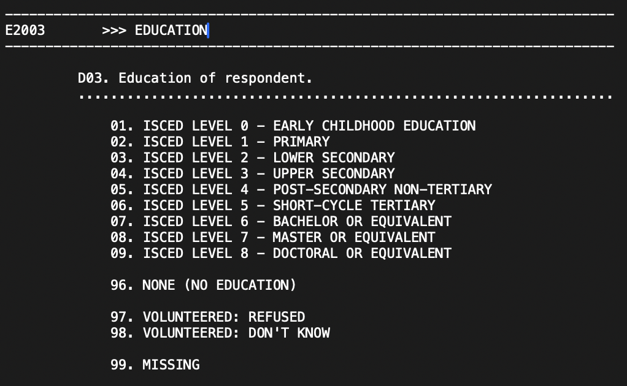

### 2.2 R functions

Going back to lab 1:

There are two ways to create new variables:

1. Using `mutate()` from `dplyr`;
2. Using `$` and assigning the new values.

Here are a few functions that come in handy in a `mutate()` call when you want to change the structure of a variable:

- `ifelse()`;
- `case_when()`.

For example: Create a dummy variable (binary 0,1) for sex:

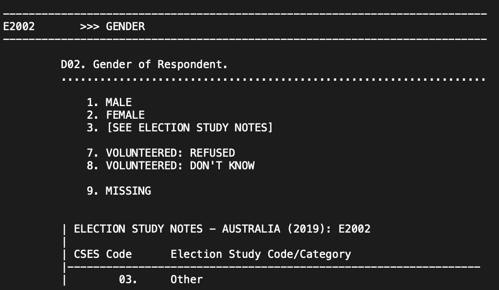

```r
cses <- import("cses5.rdata")

table(cses$E2002)
```

```
##
##     1     2     3     7     9
## 55939 58329    80   169   197
```

```r
# Base R
cses$female <- NA
cses$female[cses$E2002==2] <- 1
cses$female[cses$E2002 %in% c(1,3)] <- 0


# dplyr 1
cses <- cses |>
  mutate(female = ifelse(E2002==2,1,ifelse(E2002 %in% c(1,3),0, NA)))

# dplyr 2
cses <- cses |>
  mutate(female = case_when(E2002 == 2 ~ 1,
                            E2002 %in% c(1,3) ~ 0,
                            TRUE ~ NA))
```

### 2.3 Checking your work

- It is of utmost importance to check your work!
- If I did not emphasize this enough in other labs, let me do it now!

**USE** `table()` **to check frequencies before and after cleaning**, you can even do crosstabs:

```r
# Let's say I do this (DON'T EVER DO THIS, DON'T YOU DARE!!!!)
tmp <- cses |>
  mutate(female = case_when(E2002 == 2 ~ 1,
                            TRUE ~ 0))

table(cses$E2002,tmp$female,useNA = "ifany")
```

```
##
##         0     1
##   1 55939     0
##   2     0 58329
##   3    80     0
##   7   169     0
##   9   197     0
```

```r
# If you want to use case_when, then assign every value.
tmp <- cses |>
    mutate(female = case_when(E2002 == 2 ~ 1,
                              E2002 %in% c(1,3) ~ 0,
                              TRUE ~ NA))

table(cses$E2002,tmp$female,useNA = "ifany")
```

```
##
##         0     1  <NA>
##   1 55939     0     0
##   2     0 58329     0
##   3    80     0     0
##   7     0     0   169
##   9     0     0   197
```

```r
# Still, ifelse is much safer in its clunkyness
tmp <- cses |>
    mutate(female = ifelse(E2002==2,1,ifelse(E2002 %in% c(1,3),0, NA)))

table(cses$E2002,tmp$female,useNA = "ifany")
```

```
##
##         0     1  <NA>
##   1 55939     0     0
##   2     0 58329     0
##   3    80     0     0
##   7     0     0   169
##   9     0     0   197
```

### 2.4 Question 2.1

In the codebook, identify the following variables, and replicate the following table (only print a dataframe with the corresponding values): country; year; gender; education level; employement status; age; place of residence (urban/rural); interest in politics; ideology (self); ideology of the party the respondent voted for; income.

**Note**:

- `female` was coded 1 for female and 0 for non-female.
- `educ_low` was coded 1 for early childhood education, primary, lower secondary, or none; and 0 otherwise.
- `educ_mid` was coded 1 for upper secondary or post-secondary; and 0 otherwise.
- `educ_hig` was coded 1 for anything above post-secondary; and 0 otherwise.
- `income_low` was coded 1 for income below or equal to the first tercile of the variable by country and year; and 0 otherwise.
- `income_mid` was coded 1 for income above the first tercile and below or equal to the second tercile; and 0 otherwise.
- `income_hig` was coded 1 for income above the second tercile and 0 otherwise.
- `urban` was coded 1 for residence in a small or middle town, suburbs, or large town or city; 0 otherwise.
- `int_pol`, `ideo_lr_self`, `ideo_vote` were all rescaled to vary between 0 and 1, with one corresponding to right in the ideology variables, and to very interested for `int_pol`.

```r
library(tidyverse)
library(rio)
dat <- import("cses5.rdata") |>
  rename(country=E1006_NAM,
         year=E1008) |>
  mutate(female=ifelse(E2002==2,1,
                       ifelse(E2002 > 3, NA, 0)),
         educ_low=ifelse(E2003 %in% c(1:3,96),1,ifelse(E2003 >96,NA,0)),
         educ_mid=ifelse(E2003 %in% 4:5,1,      ifelse(E2003 >96,NA,0)),
         educ_hig=ifelse(E2003 %in% 6:9,1,      ifelse(E2003 >96,NA,0)),
         employed=ifelse(E2006 %in% c(1,2,3),1,
                         ifelse(E2006 %in% c(97,98,99),NA,0)),
         age_25less=ifelse(E2001_A<=25,1,ifelse(E2001_A >120,NA,0)),
         age_26to35=ifelse(E2001_A>25 & E2001_A<=35,1,ifelse(E2001_A >120,NA,0)),
         age_36to45=ifelse(E2001_A>35 & E2001_A<=45,1,ifelse(E2001_A >120,NA,0)),
         age_46to55=ifelse(E2001_A>45 & E2001_A<=55,1,ifelse(E2001_A >120,NA,0)),
         age_56to65=ifelse(E2001_A>55 & E2001_A<=65,1,ifelse(E2001_A >120,NA,0)),
         age_66plus=ifelse(E2001_A>65,1,ifelse(E2001_A >120,NA,0)),
         urban=ifelse(E2022 %in% c(2,3,4),1,
                      ifelse(E2022 >=7,NA,0)),
         int_pol=ifelse(E3001>=7,NA,1-((E3001-1)/3)),
         ideo_lr_self=ifelse(E3020>10,NA,E3020/10),
         ideo_vote=ifelse(E3013_LR_CSES==9,NA,(E3013_LR_CSES-1)/2)) |>
  group_by(country,year) |>
  mutate(income_low=ifelse(E2011<=quantile(E2011,c(1/3,2/3),na.rm=T)[1],1,ifelse(E2011>=99999997,NA,0)),
         income_mid=ifelse(E2011>quantile(E2011,c(1/3,2/3),na.rm=T)[1] &
                           E2011<=quantile(E2011,c(1/3,2/3),na.rm=T)[2],1,ifelse(E2011>=99999997,NA,0)),
         income_hig=ifelse(E2011>quantile(E2011,c(1/3,2/3),na.rm=T)[2],1,ifelse(E2011>=99999997,NA,0))) |>
  select(country,year,female,starts_with(c("educ","age","income")),urban,int_pol,ideo_lr_self,ideo_vote) |>
  na.omit() |>
  ungroup()


table <- DAMisc::sumStats(dat,names(dat)[c(-1,-2)])

table
```

```
## # A tibble: 17 × 11
##    variable       mean    sd   iqr   min   q25   q50   q75   max     n   nNA
##    <chr>         <dbl> <dbl> <dbl> <dbl> <dbl> <dbl> <dbl> <dbl> <int> <int>
##  1 female       0.487  0.500 1         0 0     0       1       1 51840     0
##  2 educ_low     0.214  0.410 0         0 0     0       0       1 51840     0
##  3 educ_mid     0.375  0.484 1         0 0     0       1       1 51840     0
##  4 educ_hig     0.410  0.492 1         0 0     0       1       1 51840     0
##  5 age_25less   0.0881 0.283 0         0 0     0       0       1 51840     0
##  6 age_26to35   0.161  0.368 0         0 0     0       0       1 51840     0
##  7 age_36to45   0.181  0.385 0         0 0     0       0       1 51840     0
##  8 age_46to55   0.178  0.383 0         0 0     0       0       1 51840     0
##  9 age_56to65   0.181  0.385 0         0 0     0       0       1 51840     0
## 10 age_66plus   0.211  0.408 0         0 0     0       0       1 51840     0
## 11 income_low   0.408  0.491 1         0 0     0       1       1 51840     0
## 12 income_mid   0.399  0.490 1         0 0     0       1       1 51840     0
## 13 income_hig   0.193  0.395 0         0 0     0       0       1 51840     0
## 14 urban        0.703  0.457 1         0 0     1       1       1 51840     0
## 15 int_pol      0.644  0.283 0.667     0 0.333 0.667   1       1 51840     0
## 16 ideo_lr_self 0.520  0.277 0.4       0 0.3   0.5     0.7     1 51840     0
## 17 ideo_vote    0.583  0.405 1         0 0     0.5     1       1 51840     0
```